# HW2_STAT506

# HW2

## github: https://github.com/madojames/STATS506/tree/main

## Q1

### a. implement game simulstion in different ways

Here is the 4 types of functions to generate games

```r
#' Dice game using a loop
#' @param n The number of plays
#' @return Total won/lost money

play_dice1 <- function(n){

  if(n <= 0) {return(0)}

  random_samples <- sample(1:6, n, replace = TRUE)

  SUM <- 0
  for(i in 1:n){
    SUM <- SUM -2
    if(random_samples[i] == 3 || random_samples[i] == 5) { SUM <- SUM + random_samples[i]*2}
  }

  return(SUM)
}

#' Dice game using using built-in R vectorized functions
#' @param n The number of plays
#' @return Total won/lost money

play_dice2 <- function(n){

  if(n <= 0) {return(0)}

  random_samples <- sample(1:6, n, replace = TRUE)

  D3 <- random_samples==3
  D5 <- random_samples==5

  SUM <- -n*2 + sum(D3)*6 +sum(D5)*10

  return(SUM)
}


#' Dice game using by rolling all the dice into one and collapsing the die rolls into a single table()
#' @param n The number of plays
#' @return Total won/lost money

play_dice3 <- function(n){

  if(n <= 0) {return(0)}

  random_samples <- sample(1:6, n, replace = TRUE)

  #in case any one is 0 times
  dice_factor <- factor(random_samples, levels = 1:6)

  dice_rolls <- table(dice_factor)

  SUM <- -n*2 + dice_rolls[3]*6 +dice_rolls[5]*10

  return(SUM)
}


#' Dice game using using one of the “apply” functions
#' @param n The number of plays
#' @return Total won/lost money

play_dice4 <- function(n){

  if(n <= 0) {return(0)}

  random_samples <- sample(1:6, n, replace = TRUE)

  D3 <- random_samples==3
  D5 <- random_samples==5

  D35 <- matrix(c(D3,D5),nrow = 2,byrow = TRUE)

  SUM <- -n * 2 + apply(D35,1,sum) %*% c(6,10)

  return(SUM)
}
```

### b. test if works

Here lets see if these function works using 3 and 3000

```r
#here we try 3 on each of the version to see if it works
result1 <- play_dice1(3)
print(paste("the result of Dice game using a loop is:",result1))
```

```
[1] "the result of Dice game using a loop is: 4"
```

```r
result2 <- play_dice2(3)
print(paste("the result of Dice game using built-in R functions is:",result2))
```

```
[1] "the result of Dice game using built-in R functions is: 0"
```

```r
result3 <- play_dice3(3)
print(paste("the result of Dice game using table is:",result3))
```

```
[1] "the result of Dice game using table is: 10"
```

```r
result4 <- play_dice4(3)
print(paste("the result of Dice game using apply is:",result4))
```

```
[1] "the result of Dice game using apply is: 14"
```

```r
#here we try 3000 on each of the version to see if it works
result1 <- play_dice1(3000)
print(paste("the result of Dice game using a loop is:",result1))
```

```
[1] "the result of Dice game using a loop is: 2264"
```

```r
result2 <- play_dice2(3000)
print(paste("the result of Dice game using built-in R functions is:",result2))
```

```
[1] "the result of Dice game using built-in R functions is: 2032"
```

```r
result3 <- play_dice3(3000)
print(paste("the result of Dice game using table is:",result3))
```

```
[1] "the result of Dice game using table is: 2034"
```

```r
result4 <- play_dice4(3000)
print(paste("the result of Dice game using apply is:",result4))
```

```
[1] "the result of Dice game using apply is: 1894"
```

So all version works! Great.

### c. four versions give the same result

So the function dose works! Here we try to let them be the same by setting seed.

```r
#By adding set.seed in front of each function we can control the result
set.seed(1)
result1 <- play_dice1(3)
print(paste("the result of Dice game using a loop is:",result1))
```

```
[1] "the result of Dice game using a loop is: -6"
```

```r
set.seed(1)
result2 <- play_dice2(3)
print(paste("the result of Dice game using built-in R functions is:",result2))
```

```
[1] "the result of Dice game using built-in R functions is: -6"
```

```r
set.seed(1)
result3 <- play_dice3(3)
print(paste("the result of Dice game using table is:",result3))
```

```
[1] "the result of Dice game using table is: -6"
```

```r
set.seed(1)
result4 <- play_dice4(3)
print(paste("the result of Dice game using apply is:",result4))
```

```
[1] "the result of Dice game using apply is: -6"
```

```r
#By adding set.seed in front of each function we can control the result
set.seed(1)
result1 <- play_dice1(3000)
print(paste("the result of Dice game using a loop is:",result1))
```

```
[1] "the result of Dice game using a loop is: 2162"
```

```r
set.seed(1)
result2 <- play_dice2(3000)
print(paste("the result of Dice game using built-in R functions is:",result2))
```

```
[1] "the result of Dice game using built-in R functions is: 2162"
```

```r
set.seed(1)
result3 <- play_dice3(3000)
print(paste("the result of Dice game using table is:",result3))
```

```
[1] "the result of Dice game using table is: 2162"
```

```r
set.seed(1)
result4 <- play_dice4(3000)
print(paste("the result of Dice game using apply is:",result4))
```

```
[1] "the result of Dice game using apply is: 2162"
```

We can further implement seed as a parameter in the function, here is a example using loop version. the result should be the same as above

```r
#' Dice game using a loop
#' @param n The number of plays
#' @return Total won/lost money

play_dice1_setseed <- function(n,seed=1){

  set.seed(seed)

  if(n <= 0) {return(0)}

  random_samples <- sample(1:6, n, replace = TRUE)

  SUM <- 0
  for(i in 1:n){
    SUM <- SUM -2
    if(random_samples[i] == 3 || random_samples[i] == 5) { SUM <- SUM + random_samples[i]*2}
  }

  return(SUM)
}

play_dice1_setseed(3,1)
```

```
[1] -6
```

```r
play_dice1_setseed(3000,1)
```

```
[1] 2162
```

### d. demonstrate the speed of the implementations

Use the microbenchmark package see the speed of each implementations.

```r
library(microbenchmark)

benchmark_results1 <- microbenchmark(
  model1 = play_dice1(1000),
  model1_seed = play_dice1_setseed(1000,1),
  model2 = play_dice2(1000),
  model3 = play_dice3(1000),
  model4 = play_dice4(1000),
  times = 100L  # 重复运行每个函数的次数
)


benchmark_results2 <- microbenchmark(
  model1 = play_dice1(100000),
  model1_seed = play_dice1_setseed(100000,1),
  model2 = play_dice2(100000),
  model3 = play_dice3(100000),
  model4 = play_dice4(100000),
  times = 100L  # 重复运行每个函数的次数
)
```

```r
summary(benchmark_results1)
```

```
         expr  min     lq    mean median     uq    max neval
1      model1 72.7  80.90  98.648  85.75 112.50  202.4   100
2 model1_seed 72.7  82.40 103.424  86.15 120.60  231.3   100
3      model2 39.2  48.75  96.378  54.55 134.75  577.9   100
4      model3 87.7 126.05 301.622 239.75 382.55 1799.6   100
5      model4 56.1  84.05 210.816 195.20 302.45  609.4   100
```

```r
summary(benchmark_results2)
```

```
         expr    min     lq     mean  median      uq     max neval
1      model1 7.0583 7.4341 7.831132 7.64235 7.85020 11.3049   100
2 model1_seed 6.9443 7.4435 7.829444 7.64925 8.06315 10.5014   100
3      model2 3.5785 3.9441 4.341983 4.12750 4.46050  9.2184   100
4      model3 5.2748 6.2580 6.794713 6.70445 7.22910  9.2890   100
5      model4 4.2592 5.2818 6.069811 5.64505 6.03575 23.4636   100
```

Discussion: from two bench mark test, the unit is different in two test, we can see the vector form is the fastest. It is surprising that the table version is slowest in the test for 1000. I guess the tabling is not linear time O(n) as the loop function. That’s why it is slowest first but faster than loop in larger test version. As for set seed version, it is hard to say as for 1000 it is slower but 100000 it is faster(or the opposite way, the speed changes each time and I dont know which version it appears on the final version). It should be consistent on 1000 and 100000 instead of inconsistent.

### e

In order to see whether it is a fair game, we need to see the expectation of the money for one game. Using the Monte Carlo idea, we can play the games multiple times and see the average of the money. If it is a fair game, it should be close to 0.

```r
Moneysum <- 0

# sample the game using a loop
for (i in 1:100000) {
  Moneysum <- Moneysum + play_dice1(1)
}

Mean_money <- Moneysum/100000

print(paste("the average earning of the game is",Mean_money))
```

```
[1] "the average earning of the game is 0.68264"
```

$$E(X)=1/6*(3*2+5*2)-2=0.6666667$$
From statistical calculation we know the expectation of the game is 0.666667. The Monte Carlo result is greater than 0 and is close to 0.666667. So from the Monte Carlo result this is not a fair game.

## Q2

### a. Rename the columns

```r
cars <- read.csv("cars.csv")
#head(cars)
```

```r
cars_names <- colnames(cars)
print(cars_names)
```

```
 [1] "Dimensions.Height"
 [2] "Dimensions.Length"
 [3] "Dimensions.Width"
 [4] "Engine.Information.Driveline"
 [5] "Engine.Information.Engine.Type"
 [6] "Engine.Information.Hybrid"
 [7] "Engine.Information.Number.of.Forward.Gears"
 [8] "Engine.Information.Transmission"
 [9] "Fuel.Information.City.mpg"
[10] "Fuel.Information.Fuel.Type"
[11] "Fuel.Information.Highway.mpg"
[12] "Identification.Classification"
[13] "Identification.ID"
[14] "Identification.Make"
[15] "Identification.Model.Year"
[16] "Identification.Year"
[17] "Engine.Information.Engine.Statistics.Horsepower"
[18] "Engine.Information.Engine.Statistics.Torque"
```

```r
colnames(cars) <- c("Height", "Length", "Width", "Driveline", "Engine_Type", "Hybrid", "Forward_Gears_num", "Transmission", "City", "Fuel_Type", "Highway", "Classification", "ID", "Make", "Model_Year", "Year", "Horsepower", "Torque")
#head(cars)
```

### b. Restrict the data to cars whose Fuel Type is “Gasoline”.

```r
num_before <- nrow(cars)
cars_Gas <- cars[cars$Fuel_Type == "Gasoline",]
num_after <- nrow(cars_Gas)
print(paste("num before subseting is:",num_before,"and num after subseting:",num_after))
```

```
[1] "num before subseting is: 5076 and num after subseting: 4591"
```

So we filtered on fuel type and can see the number of data decreased.

### c.Examine the distribution of highway gas mileage.

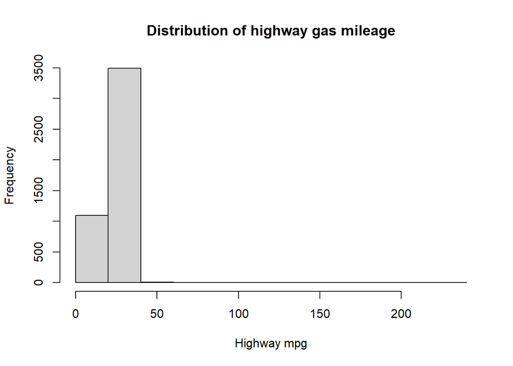

```r
hist(cars_Gas$Highway, main = "Distribution of highway gas mileage", xlab = "Highway mpg", ylab = "Frequency")
```

It is hard to see from this graph. So I did a q-q plot.

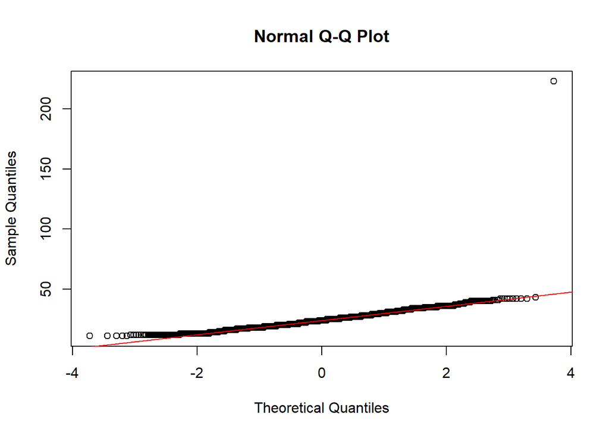

```r
# Q-Q plot
qqnorm(cars$Highway)
qqline(cars$Highway, col = "red")
```

We can see that the up-right corner has a extreme point. Let’s see what is it.

```r
table(cars_Gas$Highway)
```

```
 13  14  15  16  17  18  19  20  21  22  23  24  25  26  27  28  29  30  31  32
  9  10  22  50 138 262 281 323 274 235 371 267 405 323 302 259 167 160 161  99
 33  34  35  36  37  38  39  40  41  42 223
105 125  92  75  16  14  12  27   3   3   1
```

There is a error point with mpg as 223 which is unreasonable. So I deleted it.

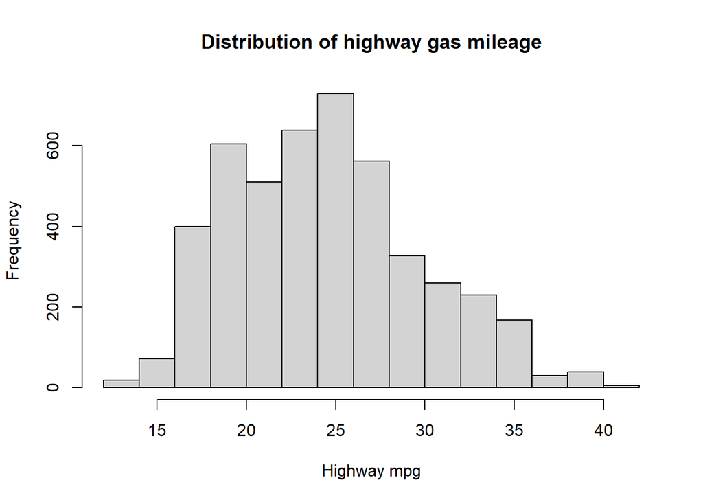

```r
cars_Gas <- cars_Gas[cars_Gas$Highway < 80,]
hist(cars_Gas$Highway, main = "Distribution of highway gas mileage", xlab = "Highway mpg", ylab = "Frequency")
```

The plot seems more reasonable right now. But it is not very alike the normal distribution.

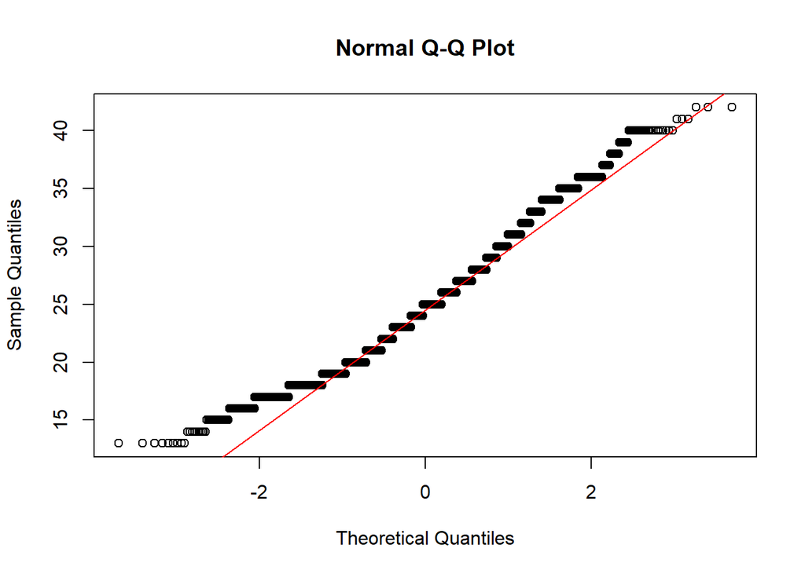

```r
# Q-Q plot
qqnorm(cars_Gas$Highway)
qqline(cars_Gas$Highway, col = "red")
```

Again from the qq plot we can see that the left tail is a little far away from the line. So it is not normal, I consider trying log and sqrt transformation.

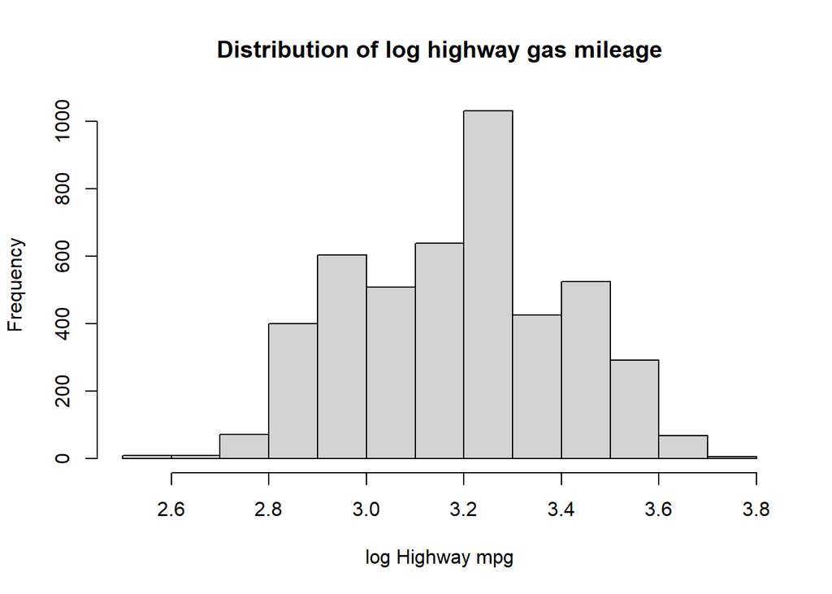

```r
hist(log(cars_Gas$Highway), main = "Distribution of log highway gas mileage", xlab = "log Highway mpg", ylab = "Frequency")
```

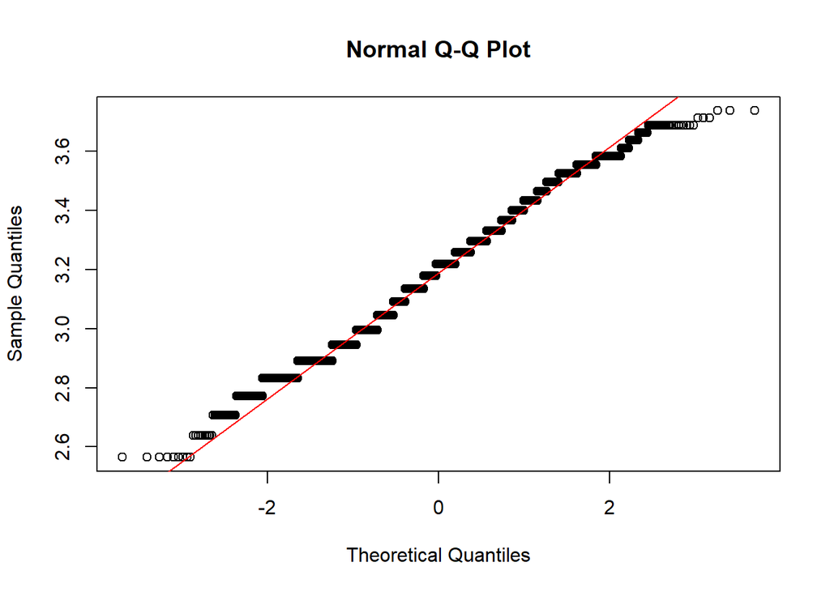

```r
qqnorm(log(cars_Gas$Highway))
qqline(log(cars_Gas$Highway), col = "red")
```

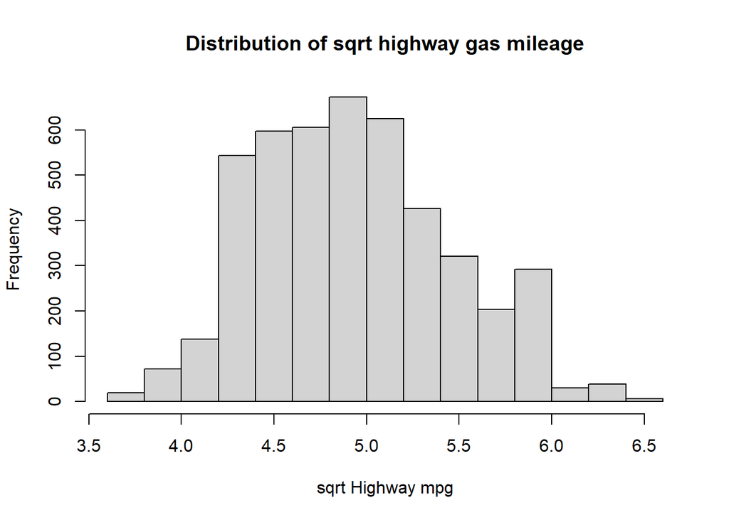

```r
hist(sqrt(cars_Gas$Highway), main = "Distribution of sqrt highway gas mileage", xlab = "sqrt Highway mpg", ylab = "Frequency")
```

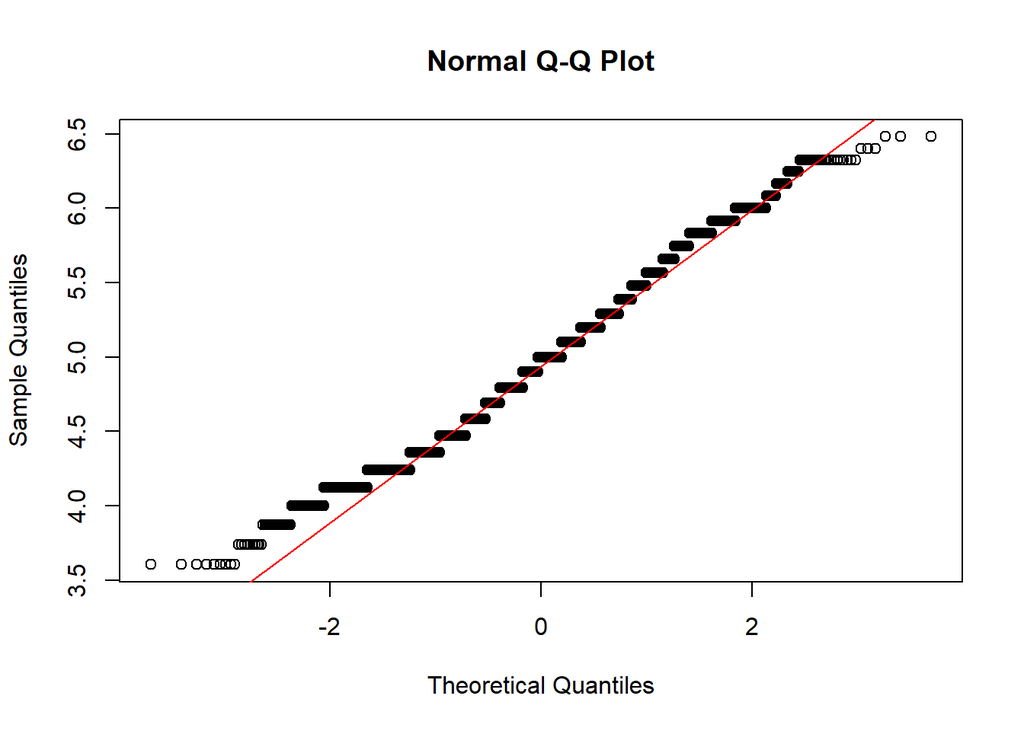

```r
qqnorm(sqrt(cars_Gas$Highway))
qqline(sqrt(cars_Gas$Highway), col = "red")
```

```r
# Shapiro-Wilk test
```

[output not shown]

### d

```r
lrm <- lm(log(Highway) ~ Torque + Horsepower + Height + Length + Width + as.factor(Year), data = cars_Gas)
summary(lrm)
```

```
Call:
lm(formula = log(Highway) ~ Torque + Horsepower + Height + Length +
    Width + as.factor(Year), data = cars_Gas)

Residuals:
     Min       1Q   Median       3Q      Max
-0.54934 -0.09280 -0.00387  0.09913  0.76803

Coefficients:
                      Estimate Std. Error t value Pr(>|t|)
(Intercept)          3.508e+00  2.144e-02 163.617  < 2e-16 ***
Torque              -2.306e-03  6.537e-05 -35.279  < 2e-16 ***
Horsepower           9.330e-04  6.757e-05  13.807  < 2e-16 ***
Height               4.116e-04  3.344e-05  12.310  < 2e-16 ***
Length               2.776e-05  2.622e-05   1.059 0.289808
Width               -9.296e-05  2.684e-05  -3.463 0.000538 ***
as.factor(Year)2010 -2.176e-02  2.008e-02  -1.084 0.278613
as.factor(Year)2011 -3.625e-03  2.005e-02  -0.181 0.856532
as.factor(Year)2012  3.999e-02  2.021e-02   1.979 0.047876 *
---
Signif. codes:  0 '***' 0.001 '**' 0.01 '*' 0.05 '.' 0.1 ' ' 1

Residual standard error: 0.1366 on 4581 degrees of freedom
Multiple R-squared:  0.582, Adjusted R-squared:  0.5813
F-statistic: 797.3 on 8 and 4581 DF,  p-value: < 2.2e-16
```

discussion: So from the estimated coefficient we can see that the relationship between Torque and log(Highway) is negative. This means that the mpg will increase when all other factors hold still and the Torque decreases. And if all other stay still and torque decreases for 1 unit, the log(Highway) will increase 0.002306 unit.

### e

```r
lrm1 <- lm(log(Highway) ~ Torque*Horsepower + Height + Length + Width + as.factor(Year), data = cars_Gas)
table(cars_Gas$Year)
```

```
2009 2010 2011 2012
  48 1633 1793 1116
```

The number for year 2011 has the most samples. So I pick year 2011.

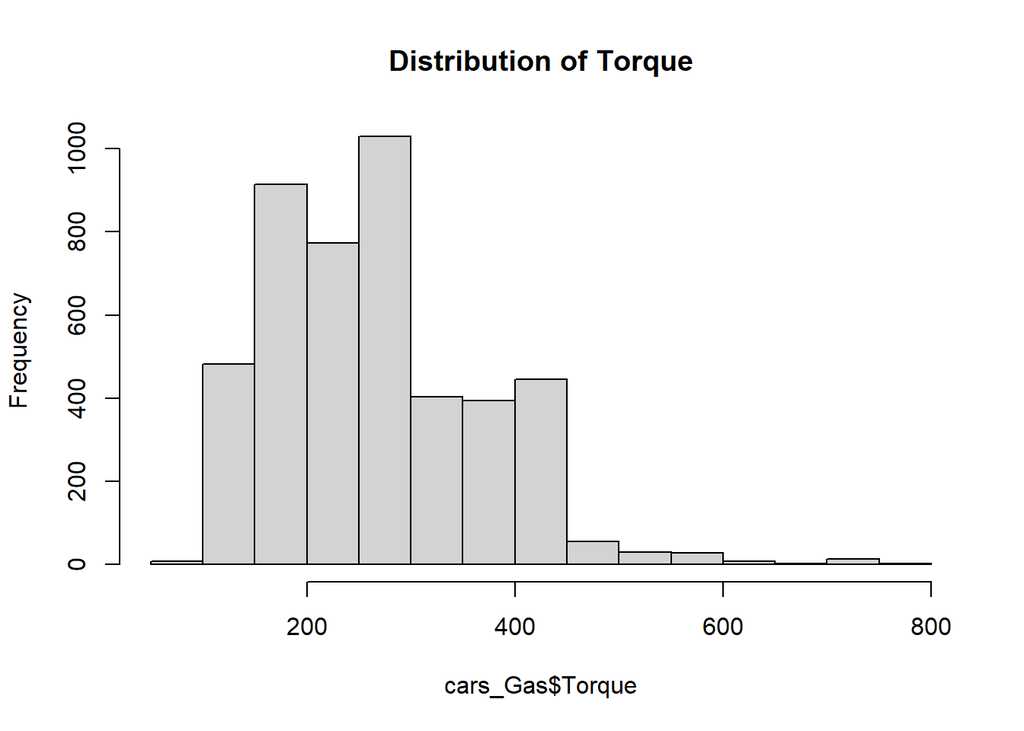

```r
#table(cars_Gas$Torque)
#table(cars_Gas$Horsepower)
hist(cars_Gas$Torque, main = "Distribution of Torque")
```

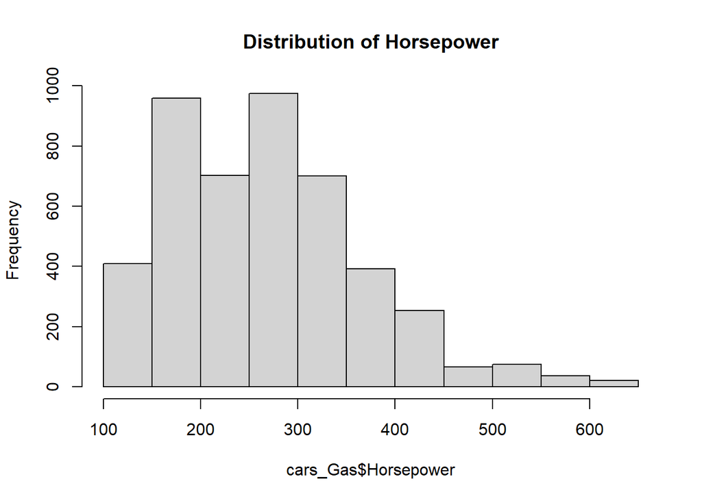

```r
hist(cars_Gas$Horsepower, main = "Distribution of Horsepower")
```

The Torque range should be as 200 300 400 for emmip function. And pick 200 300 400 for Horsepower.

I try both the packages mentioned on class.

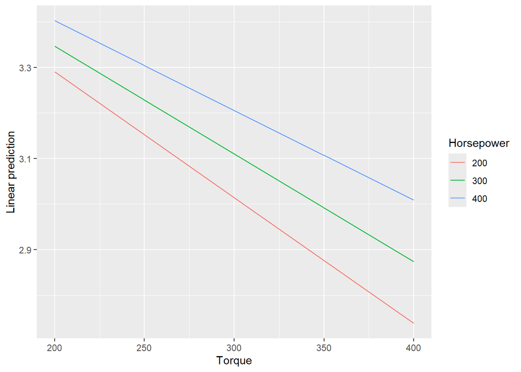

```r
library(emmeans)
emmip(lrm1, Horsepower ~ Torque, at = list(Torque = c(200,300,400),Horsepower=c(200,300,400)))
```

```
Using data cars_Gas from global environment. This could cause incorrect
results if cars_Gas has been altered since the model was fit. You can
manually provide the data to the "data =" argument.
```

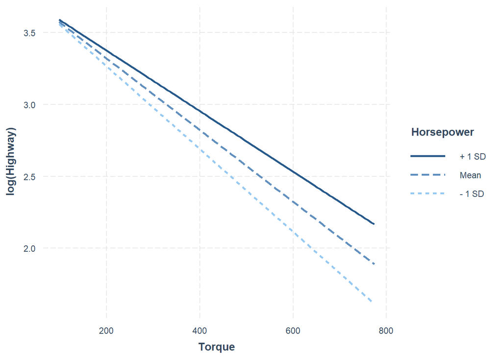

```r
library(interactions)
interact_plot(lrm1, pred = Torque, modx = Horsepower,at = list(Year = 2011))
```

### f

```r
X <- model.matrix(log(Highway) ~ Torque + Horsepower + Height + Length + Width + as.factor(Year), data = cars_Gas)
Y <- cars_Gas$Highway
Y <- log(Y)
beta <- solve(t(X)%*%X)%*%t(X)%*%Y
print(beta)
```

```
                             [,1]
(Intercept)          3.508331e+00
Torque              -2.306333e-03
Horsepower           9.329999e-04
Height               4.115953e-04
Length               2.776194e-05
Width               -9.295624e-05
as.factor(Year)2010 -2.176234e-02
as.factor(Year)2011 -3.625194e-03
as.factor(Year)2012  3.999171e-02
```

```r
print(lrm$coefficients)
```

```
        (Intercept)              Torque          Horsepower              Height
       3.508331e+00       -2.306333e-03        9.329999e-04        4.115953e-04
             Length               Width as.factor(Year)2010 as.factor(Year)2011
       2.776194e-05       -9.295624e-05       -2.176234e-02       -3.625194e-03
as.factor(Year)2012
       3.999171e-02
```

We can see they are the same for the two method